# Rapport d’Analyse : DPE 73 & 74

Rafaël Sanz & Quentin Zavagno

2025-11-16

# Introduction

Dans le cadre du défi lancé par **Enedis** autour de l’évaluation de l’impact du Diagnostic de Performance Énergétique (DPE) sur les consommations des logements, la société **GreenTech Solutions** nous a confié la réalisation d’une étude statistique et d’une application interactive RShiny.

Le présent rapport constitue le premier livrable attendu : une analyse claire et structurée des performances énergétiques des logements situés en **Savoie (73)** et en **Haute-Savoie (74)**.

Cette étude se concentre sur les données publiques issues des DPE « logements neufs » et « logements existants », enrichies par la Base Adresse Nationale.

L’objectif est double :

- **décrire et comparer les profils énergétiques** des deux départements ;
- **identifier les facteurs influençant les coûts énergétiques**, notamment l’étiquette DPE, la période de construction et la surface habitable.

Pour répondre à ces objectifs, le rapport s’appuie sur :

- des **KPI essentiels** (coûts, GES, surfaces, répartition des classes DPE) ;
- des **visualisations variées** : histogrammes, diagrammes en barres, nuages de points, graphiques comparatifs 73/74 ;
- des **statistiques bivariées**, dont la corrélation entre surface et coût de chauffage ;
- des analyses dynamiques basées sur les **filtres définis par l’utilisateur** : département, code postal et type de logement (ancien, neuf ou les deux).

Les résultats qui suivent mettent en lumière les tendances générales du territoire, ainsi que les spécificités locales de chaque département.

**Paramètres :**

- Département : Les deux
- Type de logement : Les deux

# Indicateurs clés

| Indicateur | Valeur |
| --- | --- |
| Nombre total de logements | 326 022 |
| Coût annuel moyen (5 usages) | 1 956 € |
| GES total moyen | 2 693 kgCO2/an |
| GES moyen par m² | 25.78 kgCO2/m²/an |
| Surface habitable moyenne | 75.3 m² |

# Répartition des coûts énergétiques

## Tableau des coûts

Part moyenne des coûts par usage (%)

| departement | Chauffage | ECS | Refroidissement | Éclairage | Auxiliaires |
| --- | --- | --- | --- | --- | --- |
| 73 | 60.1 | 29.1 | 0.1 | 4.5 | 9.3 |
| 74 | 60.1 | 28.4 | 0.0 | 5.4 | 8.9 |

# Répartition des émissions GES

| departement | GES_total | GES_chauffage_pct | GES_ECS_pct |
| --- | --- | --- | --- |
| 73 | 2520.2 kgCO2/an | 67.7 % | 27.1 % |
| 74 | 2795.5 kgCO2/an | 67 % | 29.7 % |

# Répartition des Étiquettes DPE

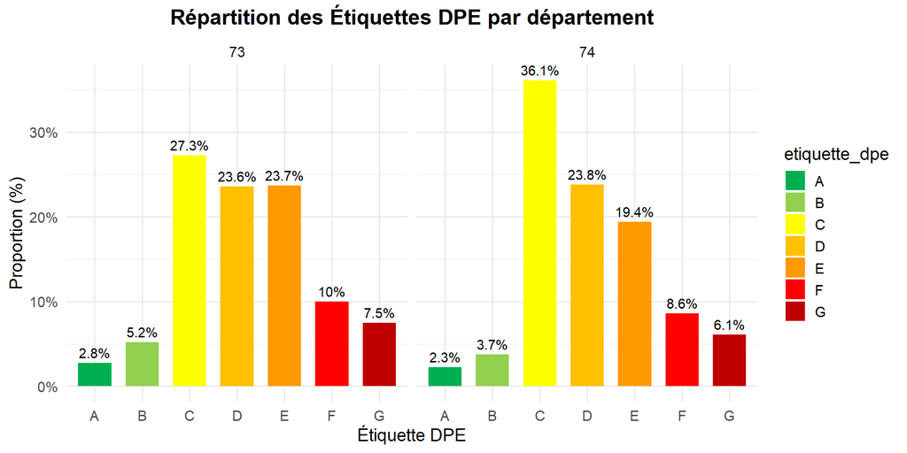

# Coût annuel moyen par étiquette

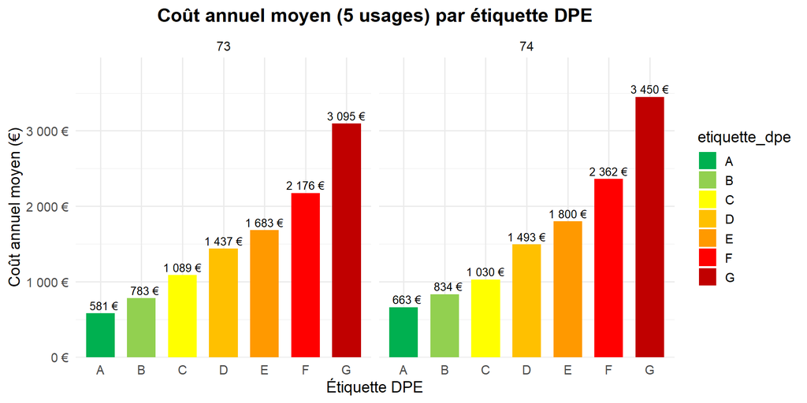

# Répartition par période de construction

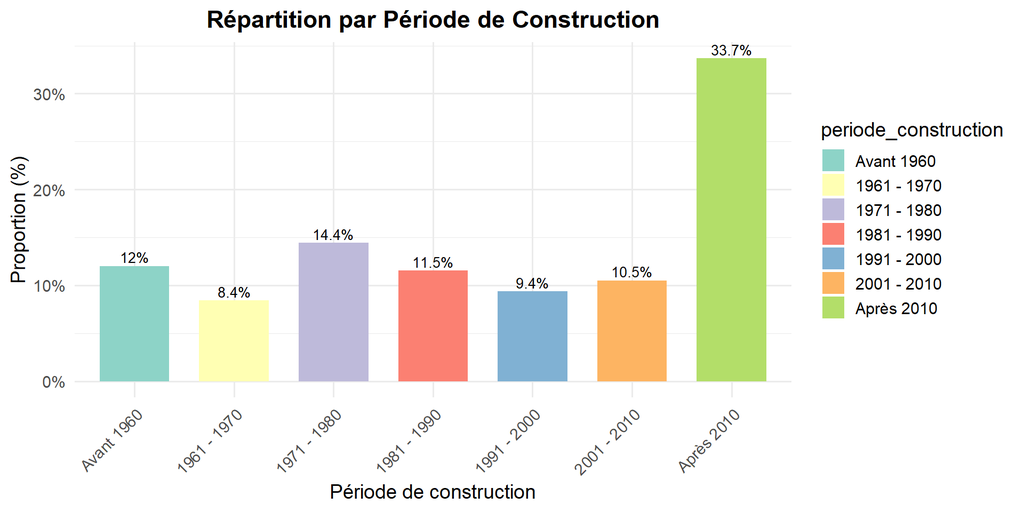

### Tableau de répartion des logements du 73 et 74 en fonction de la période de construction

| periode_construction | n_73 | n_74 | pct_73 | pct_74 |
| --- | --- | --- | --- | --- |
| Avant 1960 | 13723 | 14915 | 15.7 | 9.9 |
| 1961 - 1970 | 8537 | 11594 | 9.8 | 7.7 |
| 1971 - 1980 | 15660 | 18760 | 17.9 | 12.4 |
| 1981 - 1990 | 12789 | 14751 | 14.6 | 9.8 |
| 1991 - 2000 | 8547 | 13764 | 9.8 | 9.1 |
| 2001 - 2010 | 8086 | 16981 | 9.3 | 11.2 |
| Après 2010 | 20058 | 60316 | 22.9 | 39.9 |

# Corrélation Surface / Coût Chauffage

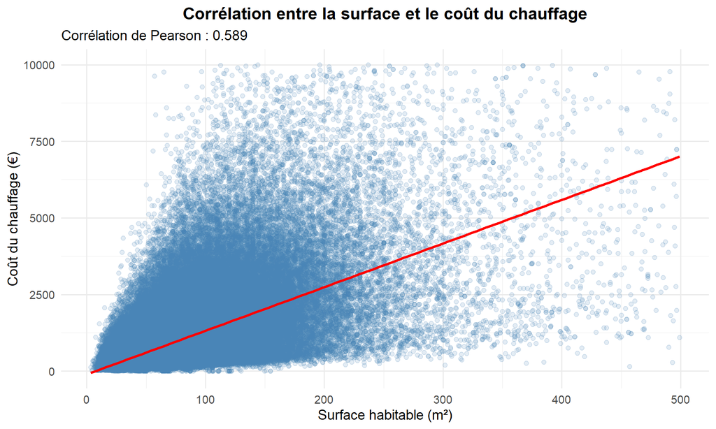

# Conclusion

Cette analyse met en évidence plusieurs enseignements clés concernant la performance énergétique des logements étudiés.

**1. Répartition des DPE**  
Les étiquettes *C, D* et *E* regroupent la majorité des logements, tandis que les DPE *F* et *G* — plus énergivores — restent significativement minoritaires, mais présentent des coûts nettement supérieurs.  
Cela confirme que la performance énergétique exerce un impact direct sur le niveau de dépenses annuelles.

**2. Différences entre Savoie et Haute-Savoie**  
Lorsque les deux départements sont analysés conjointement, des écarts apparaissent : - La **Haute-Savoie (74)** concentre proportionnellement davantage de logements récents (période *Après 2010*).  
- La **Savoie (73)** présente une part légèrement plus élevée de bâtiments anciens (*Avant 1960*).

Ces différences structurelles influencent partiellement les niveaux de consommation et les profils énergétiques observés.

**3. Coûts énergétiques**  
Le coût annuel moyen suit une progression claire selon les étiquettes DPE :  
→ Les logements F et G se distinguent par des coûts beaucoup plus élevés que les classes A à D, reflétant une moindre efficacité énergétique.

**4. Corrélation surface – coût chauffage**  
L’analyse met en évidence une relation positive entre la surface habitable et le coût du chauffage.  
Le coefficient de corrélation de Pearson est : **0.589**.  
Cela traduit une **corrélation modérée**, logique : les logements plus grands tendent à générer des dépenses plus élevées, tout en restant sensibles à la qualité de l’isolation et au type d’énergie utilisée.

**En synthèse**, ce rapport confirme l’importance des caractéristiques structurelles (période de construction, surface, typologie des logements) et de l’étiquette DPE dans l’explication des performances énergétiques observées.

Rapport généré automatiquement à partir des données filtrées.